# Step1:Read the column description and ensure you understand each attribute well

# Box plot to check the outliers in independent numerical variables

```
Age              AxesSubplot(0.125,0.657941;0.168478x0.222059)
Experience    AxesSubplot(0.327174,0.657941;0.168478x0.222059)
Income        AxesSubplot(0.529348,0.657941;0.168478x0.222059)
Family        AxesSubplot(0.731522,0.657941;0.168478x0.222059)
CCAvg            AxesSubplot(0.125,0.391471;0.168478x0.222059)
Mortgage      AxesSubplot(0.327174,0.391471;0.168478x0.222059)
dtype: object
```

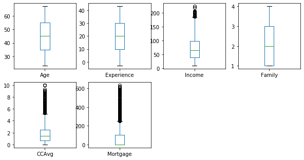

```python
#box plot for all the independent variable
df.plot(kind= 'box' , subplots=True,layout=(3,4), sharex=False, sharey=False, figsize=(10,8))
```

Inference from above box plots :

1. There is no outliers for "Age" and "Experience"
2. Income has some outliers.
3. CcAvg and mortgage columns have large no of outliers and mortgage is highly right skwed

# Distribution of categorical variables

```python
#Education, Personal Loan, Securities Account, CD Account,Online, Credit Card
```

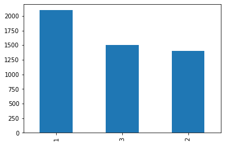

```python
df['Education'].value_counts().plot(kind='bar')
```

Maximum customers are "undergrade" while "graduate" and "advanced/professional" people are almost in same ratio in the targeted customers

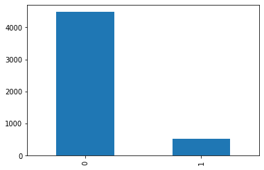

```python
df['Securities Account'].value_counts().plot(kind='bar')
```

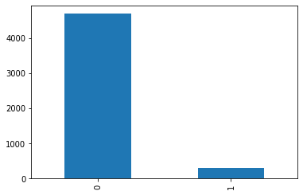

```python
df['CD Account'].value_counts().plot(kind='bar')
```

# 4698 out of 5000 targeted customers did not have certificate of deposit account with the bank.

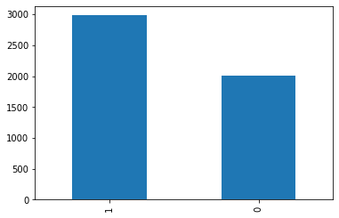

```python
df['Online'].value_counts().plot(kind='bar')
```

60% of the targeted Customers used the internet banking facilities

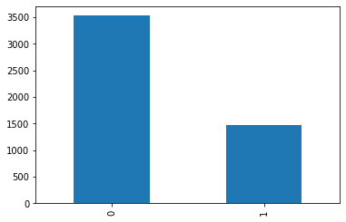

```python
df['CreditCard'].value_counts().plot(kind='bar')
```

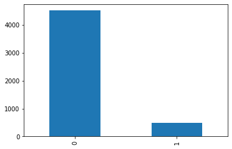

```python
df['Personal Loan'].value_counts().plot(kind='bar')
```

No of the customers who accepted the personal loan is very less as compare to the customers who did not accept it.